# Analyse der Kundenabwanderung eines Telekommunikationsunternehmens mit fiktiven Daten

**Szenario:** Der fiktive Telekommunikationsanbieter Teleconfia versucht in den USA Fuß zu fassen. Als erstes Probegebiet wurde Florida ausgewählt. Neue Kunden konnten ein Jahr lang zu sehr günstigen Konditionen Handys im Teleconfia-Netz nutzen. Nicht alle Kunden sind ein Jahr lang geblieben. Viele sind abgewandert. Dieser Kundenabwanderung, auch *churn* genannt, soll durch zwei Marketingkampagnen entgegengewirkt werden.

Die erste Marketingkampagne zielt auf Stadtgebiete, in denen Plakate geklebt werden sollen. Ein Stadtgebiet ist eine kleine Stadt bzw. ein Stadtteil einer Großstadt. Die vier Stadtgebiete mit der höchsten Kundenabwanderung sollen ausgewählt werden, um in ihnen die Marketingkampagne zu starten. Die zweite Marketingkampagne zielt auf individuelle Kunden. Jene Kunden, die wahrscheinlich Teleconfia verlassen werden, sollen angerufen werden, um mit ihnen Sonderkonditionen abzustimmen.

Um diese Ziele zu erreichen, werden die Stadtgebiete bzw. diejenigen Kunden identifiziert, für welche Marketingkampagnen lanciert werden sollen. Dazu wird mittels explorativer Analysen bestimmt, welche Datenreihen (Variablen) für die Entscheidung herangezogen werden sollten. Daneben werden Schwellenwerte in Variablen ermittelt, ab denen die Kunden kontaktiert werden sollten. Mit Hilfe einer logistischen Regression wird zum Abschluss bestimmt, ab welchem kritischen Wert ein Kunde wahrscheinlicher abwandern wird als nicht abzuwandern. Visualisierungen veranschaulichen die gefundenen Ergebnisse.

Die Daten werden in einer Datenbank namens *telco_churn.db* zur Verfügung gestellt. Das folgende Datenwörterbuch erklärt die Struktur.

Tabelle `churn_data`:

| Spaltennummer | Spaltenname | Datenniveau | Beschreibung |
| --- | --- | --- | --- |
| 0 | `account_length` | numerisch (`int`) | Anzahl der Tage, seit denen der Kunde ein Konto beim Telekommunikationsanbieter hat |
| 1 | `international_plan` | kategorisch (nominal) | Vertrag mit Sonderkonditionen für günstigere Anrufe ins Ausland |
| 2 | `voice_mail_plan` | kategorisch (nominal) | Vertrag mit Sonderkonditionen für mehr Speicher in der Mailbox |
| 3 | `number_vmail_messages` | numerisch (`int`) | Anzahl der Nachrichten in der Mailbox |
| 4 | `total_day_minutes` | numerisch (`float`) | Dauer (Minuten) aller Anrufe von 8 Uhr bis 16 Uhr |
| 5 | `total_day_calls` | numerisch (`int`) | Anzahl aller Anrufe von 8 Uhr bis 16 Uhr |
| 6 | `total_day_charge` | numerisch (`float`) | Berechnete Kosten für alle Anrufe von 8 Uhr bis 16 Uhr |
| 7 | `total_eve_minutes` | numerisch (`float`) | Dauer (Minuten) aller Anrufe von 16 Uhr bis 22 Uhr |
| 8 | `total_eve_calls` | numerisch (`int`) | Anzahl aller Anrufe von 16 Uhr bis 22 Uhr |
| 9 | `total_eve_charge` | numerisch (`float`) | Berechnete Kosten für alle Anrufe von 16 Uhr bis 22 Uhr |
| 10 | `total_night_minutes` | numerisch (`float`) | Dauer (Minuten) aller Anrufe von 22 Uhr bis 8 Uhr |
| 11 | `total_night_calls` | numerisch (`int`) | Anzahl aller Anrufe von 22 Uhr bis 8 Uhr |
| 12 | `total_night_charge` | numerisch (`float`) | Berechnete Kosten für alle Anrufe von 22 Uhr bis 8 Uhr |
| 13 | `customer_service_calls` | numerisch (`int`) | Anzahl der Anrufe beim Kundenservice, z. B. wegen technischer Störungen |
| 14 | `churn` | kategorisch (nominal) | Abwanderung des Kunden (0=nein, 1=ja) |
| 15 | `local_area_code` | kategorisch (nominal) | Ortsvorwahl |
| 16 | `phone_num` | kategorisch (nominal) | Telefonnummer des Kunden ohne Ortsvorwahl |

Tabelle `cities`:

| Spaltennummer | Spaltenname | Datenniveau | Beschreibung |
| --- | --- | --- | --- |
| 0 | `city` | kategorisch (nominal) | Stadtgebiete |
| 1 | `area_code` | kategorisch (nominal) | Ortsvorwahl |

## **1)** **Einlesen** der Daten

```python
#1. Prüfen, ob die Datenbank im Heimatordner liegt:
import os
os.listdir()
```

```
['example_db.db',
 'telco_churn.db',
 '01-exercise.ipynb',
 '02-exercise.ipynb',
 '.ipynb_checkpoints',
 'telco_churn_db.db',
 'Codebook.txt',
 'Matplotlib_LS.ipynb',
 'results_teleconfia.png',
 '02-exercise-Copy1.ipynb']
```

```python
#2. Sie ist da und kann nun über eine SQL Abfrage eingelesen werden:
import sqlalchemy as sa
engine = sa.create_engine('sqlite:///telco_churn.db')
connection = engine.connect()
```

```python
#3. Prüfen, welche Tabellen die Datenbank enthält:
inspector = sa.inspect(engine)
table_names = inspector.get_table_names()
print(table_names)
```

```
['churn_data', 'cities']
```

```python
#4. Daten mit pandas in einem Dataframe einlesen und dabei die beiden Tabellen der Datenbank zusammenführen.
#Vorher testweises Einlesen der ersten Zeilen, um einen Überblick zu bekommen.

import pandas as pd
query_string = '''SELECT *
FROM churn_data
LIMIT 5'''
df = pd.read_sql(query_string, connection)
df
```

|  | account_length | international_plan | voice_mail_plan | number_vmail_messages | total_day_minutes | total_day_calls | total_day_charge | total_eve_minutes | total_eve_calls | total_eve_charge | total_night_minutes | total_night_calls | total_night_charge | customer_service_calls | churn | local_area_code | phone_num |
| --- | --- | --- | --- | --- | --- | --- | --- | --- | --- | --- | --- | --- | --- | --- | --- | --- | --- |
| 0 | 131.0 | no | no | 0.0 | 187.9 | 110.0 | 31.94 | 200.5 | 101.0 | 17.04 | 202.6 | 125.0 | 9.12 | 2.0 | 0 | 850.0 | 1473.0 |
| 1 | 63.0 | yes | yes | 21.0 | 151.5 | 99.0 | 25.76 | 147.8 | 89.0 | 12.56 | 210.4 | 114.0 | 9.47 | 1.0 | 0 | 786.0 | 8029.0 |
| 2 | 13.0 | no | no | 0.0 | 303.2 | 133.0 | 51.54 | 170.5 | 86.0 | 14.49 | 227.6 | 80.0 | 10.24 | 0.0 | 1 | 904.0 | 7468.0 |
| 3 | 129.0 | no | no | 0.0 | 159.1 | 100.0 | 27.05 | 202.5 | 90.0 | 17.21 | 233.1 | 96.0 | 10.49 | 2.0 | 0 | 305.0 | 4979.0 |
| 4 | 120.0 | no | yes | 28.0 | 215.8 | 123.0 | 36.69 | 285.2 | 76.0 | 24.24 | 192.1 | 78.0 | 8.64 | 1.0 | 0 | 239.0 | 9620.0 |

```python
#Die gleiche Prozedur mit der Tabelle 'cities'
query_string = '''SELECT *
FROM cities
LIMIT 5'''
df = pd.read_sql(query_string, connection)
df
```

|  | city | area_code |
| --- | --- | --- |
| 0 | Orlando1 | 321 |
| 1 | Orlando2 | 407 |
| 2 | Miami1 | 305 |
| 3 | Miami2 | 786 |
| 4 | Jacksonville | 904 |

```python
#Beide Tabelle lassen sich über den area_code zusammenführen, dann enthält der Dataframe auch den Namen des Stadtgebietes.
#Das ist anschaulicher für die Berichterstattung als der dreistellige Zahlencode.
```

```python
#5.Daten mit pandas in einem Dataframe einlesen und dabei die beiden Tabellen der Datenbank zusammenführen.
# Schlüsselvariable (ON) ist area_code

query_string = '''SELECT *
FROM cities
JOIN churn_data
ON cities.area_code = churn_data.local_area_code'''
df = pd.read_sql(query_string, connection)
df.head()
```

|  | city | area_code | account_length | international_plan | voice_mail_plan | number_vmail_messages | total_day_minutes | total_day_calls | total_day_charge | total_eve_minutes | total_eve_calls | total_eve_charge | total_night_minutes | total_night_calls | total_night_charge | customer_service_calls | churn | local_area_code | phone_num |
| --- | --- | --- | --- | --- | --- | --- | --- | --- | --- | --- | --- | --- | --- | --- | --- | --- | --- | --- | --- |
| 0 | Orlando1 | 321 | 1.0 | no | no | 0.0 | 182.1 | 106.0 | 30.96 | 134.9 | 106.0 | 11.47 | 152.3 | 75.0 | 6.85 | 5.0 | 1 | 321.0 | 4254.0 |
| 1 | Orlando1 | 321 | 11.0 | no | yes | 38.0 | 209.8 | 130.0 | 35.67 | 196.6 | 84.0 | 16.71 | 233.0 | 79.0 | 10.49 | 1.0 | 0 | 321.0 | 4310.0 |
| 2 | Orlando1 | 321 | 12.0 | yes | no | 0.0 | 216.7 | 117.0 | 36.84 | 116.5 | 126.0 | 9.90 | 220.0 | 110.0 | 9.90 | 2.0 | 0 | 321.0 | 5211.0 |
| 3 | Orlando1 | 321 | 21.0 | no | yes | 31.0 | 135.9 | 90.0 | 23.10 | 271.0 | 84.0 | 23.04 | 179.1 | 89.0 | 8.06 | 6.0 | 0 | 321.0 | 5976.0 |
| 4 | Orlando1 | 321 | 22.0 | no | no | 0.0 | 181.8 | 108.0 | 30.91 | 198.6 | 148.0 | 16.88 | 206.6 | 96.0 | 9.30 | 2.0 | 0 | 321.0 | 9506.0 |

```python
df.to_csv('churn_data.csv')
```

## **2)** **Überprüfung** und **Bereinigung** der Daten

```python
#Ablaufplan für Überprüfung und Bereinigung:

# Daten erkunden: Datenformate checken und ggf. anpassen
# Missings aufspüren und damit umgehen
# Unplausible Werte aufspüren und damit umgehen
```

```python
#1. Erkunden
print(df.shape)
#Es handelt sich um einen Datensatz mit 3333 Fällen (Zeilen, Kunden) und 19 Variablen (Spalten).

print(df.dtypes)
#Die meisten Spalten sind im Fließkomma Format vorhanden. Drei Variablen haben das object Format, da in Ihnen str gespeicht sind
#(die Stadtnamen und no und yes). area_code und churn sind ganzzahlige Integer. Später wird es wahrscheinlich sinnvoll die object
#Variablen in Kategorien (category) umzuwandeln - im Fall der Städtenamen - oder in int64 (0 für no und 1 für yes) falls diese
#Variablen in Berechnungen wie bspw. Regressionen benutzt werden.

print(df.loc[:,'city'].unique())
#Es gibt zwölf verschiedene Stadtgebiete
print(df.loc[:,'international_plan'].unique())
#Es gibt nur no und yes als Antworten (Werte)
print(df.loc[:,'voice_mail_plan'].unique())
#Hier gibt es ebenfalls nur no und yes als Antworten (Werte)
```

```
(3333, 19)
city                       object
area_code                   int64
account_length            float64
international_plan         object
voice_mail_plan            object
number_vmail_messages     float64
total_day_minutes         float64
total_day_calls           float64
total_day_charge          float64
total_eve_minutes         float64
total_eve_calls           float64
total_eve_charge          float64
total_night_minutes       float64
total_night_calls         float64
total_night_charge        float64
customer_service_calls    float64
churn                       int64
local_area_code           float64
phone_num                 float64
dtype: object
['Orlando1' 'Orlando2' 'Miami1' 'Miami2' 'Jacksonville' 'Tampa'
 'West Palm Beach' 'Daytona Beach' 'Clearwater' 'Sarasota' 'Cape Coral'
 'Tallahassee']
['no' 'yes']
['no' 'yes']
```

```python
#2. Umwandeln der city Variable von object in category type:

df.loc[:, 'city'] = df.loc[:, 'city'].astype('category')
df.dtypes
```

```
city                      category
area_code                    int64
account_length             float64
international_plan          object
voice_mail_plan             object
number_vmail_messages      float64
total_day_minutes          float64
total_day_calls            float64
total_day_charge           float64
total_eve_minutes          float64
total_eve_calls            float64
total_eve_charge           float64
total_night_minutes        float64
total_night_calls          float64
total_night_charge         float64
customer_service_calls     float64
churn                        int64
local_area_code            float64
phone_num                  float64
dtype: object
```

```python
#3. Missing values aufspüren

import numpy as np

print(df.isna().sum())
#Es gibt nur wenige Missings. Am meisten (n=22) noch bei number_vmail_messages

#Anzeige der Zeilen mit Missings irgendwo (any)
mask = df.isna().any(axis=1)
df_nan = df[mask]
df_nan
```

```
city                       0
area_code                  0
account_length             0
international_plan         0
voice_mail_plan            0
number_vmail_messages     22
total_day_minutes          0
total_day_calls           11
total_day_charge           0
total_eve_minutes          0
total_eve_calls            8
total_eve_charge           0
total_night_minutes        0
total_night_calls          5
total_night_charge         0
customer_service_calls     0
churn                      0
local_area_code            0
phone_num                  0
dtype: int64
```

|  | city | area_code | account_length | international_plan | voice_mail_plan | number_vmail_messages | total_day_minutes | total_day_calls | total_day_charge | total_eve_minutes | total_eve_calls | total_eve_charge | total_night_minutes | total_night_calls | total_night_charge | customer_service_calls | churn | local_area_code | phone_num |
| --- | --- | --- | --- | --- | --- | --- | --- | --- | --- | --- | --- | --- | --- | --- | --- | --- | --- | --- | --- |
| 115 | Orlando1 | 321 | 89.0 | no | no | 0.0 | 129.2 | NaN | 21.96 | 214.1 | 68.0 | 18.20 | 214.9 | 100.0 | 9.67 | 5.0 | 1 | 321.0 | 2016.0 |
| 229 | Orlando1 | 321 | 127.0 | no | no | NaN | 139.6 | 94.0 | 23.73 | 240.9 | 112.0 | 20.48 | 127.1 | 88.0 | 5.72 | 2.0 | 0 | 321.0 | 9462.0 |
| 318 | Orlando2 | 407 | 45.0 | no | no | NaN | 112.8 | 108.0 | 19.18 | 218.8 | 120.0 | 18.60 | 240.2 | 106.0 | 10.81 | 2.0 | 0 | 407.0 | 9501.0 |
| 341 | Orlando2 | 407 | 58.0 | no | no | 0.0 | 131.9 | NaN | 22.42 | 167.6 | 107.0 | 14.25 | 205.9 | 106.0 | 9.27 | 3.0 | 0 | 407.0 | 1134.0 |
| 432 | Orlando2 | 407 | 95.0 | no | no | 0.0 | 149.2 | NaN | 25.36 | 260.7 | 116.0 | 22.16 | 201.0 | 120.0 | 9.05 | 1.0 | 0 | 407.0 | 7803.0 |
| 575 | Orlando2 | 407 | 149.0 | no | no | 0.0 | 196.3 | NaN | 33.37 | 136.8 | 96.0 | 11.63 | 154.7 | 87.0 | 6.96 | 2.0 | 0 | 407.0 | 5930.0 |
| 722 | Miami1 | 305 | 93.0 | no | no | NaN | 114.3 | 100.0 | 19.43 | 221.1 | 103.0 | 18.79 | 126.3 | 88.0 | 5.68 | 0.0 | 0 | 305.0 | 3880.0 |
| 740 | Miami1 | 305 | 100.0 | no | no | NaN | 216.2 | 107.0 | 36.75 | 215.6 | 84.0 | 18.33 | 138.4 | 127.0 | 6.23 | 0.0 | 0 | 305.0 | 6255.0 |
| 780 | Miami1 | 305 | 117.0 | no | no | 0.0 | 168.8 | NaN | 28.70 | 241.4 | 107.0 | 20.52 | 204.8 | 106.0 | 9.22 | 0.0 | 0 | 305.0 | 2716.0 |
| 784 | Miami1 | 305 | 119.0 | no | no | NaN | 230.4 | 117.0 | 39.17 | 225.0 | 101.0 | 19.13 | 198.5 | 111.0 | 8.93 | 3.0 | 0 | 305.0 | 4795.0 |
| 834 | Miami1 | 305 | 142.0 | no | no | NaN | 216.8 | 134.0 | 36.86 | 187.8 | 106.0 | 15.96 | 138.1 | 108.0 | 6.21 | 0.0 | 0 | 305.0 | 1009.0 |
| 959 | Miami2 | 786 | 85.0 | no | no | NaN | 209.8 | 82.0 | 35.67 | 194.5 | 94.0 | 16.53 | 200.4 | 85.0 | 9.02 | 0.0 | 0 | 786.0 | 5826.0 |
| 1000 | Miami2 | 786 | 98.0 | no | no | 0.0 | 0.0 | 0.0 | 0.00 | 159.6 | NaN | 13.57 | 167.1 | 88.0 | 7.52 | 4.0 | 1 | 786.0 | 2555.0 |
| 1055 | Miami2 | 786 | 118.0 | no | no | NaN | 205.2 | 115.0 | 34.88 | 184.8 | 137.0 | 15.71 | 176.1 | 115.0 | 7.92 | 0.0 | 0 | 786.0 | 4509.0 |
| 1095 | Miami2 | 786 | 133.0 | no | no | 0.0 | 187.0 | 65.0 | 31.79 | 141.4 | 128.0 | 12.02 | 238.2 | NaN | 10.72 | 2.0 | 0 | 786.0 | 3161.0 |
| 1183 | Jacksonville | 904 | 44.0 | no | no | 0.0 | 204.6 | NaN | 34.78 | 205.2 | 94.0 | 17.44 | 164.6 | 84.0 | 7.41 | 0.0 | 0 | 904.0 | 4146.0 |
| 1198 | Jacksonville | 904 | 55.0 | no | no | 0.0 | 175.6 | NaN | 29.85 | 161.8 | 118.0 | 13.75 | 289.5 | 55.0 | 13.03 | 0.0 | 0 | 904.0 | 6109.0 |
| 1291 | Jacksonville | 904 | 93.0 | no | no | NaN | 164.9 | 68.0 | 28.03 | 210.4 | 86.0 | 17.88 | 229.4 | 104.0 | 10.32 | 2.0 | 0 | 904.0 | 9710.0 |
| 1327 | Jacksonville | 904 | 100.0 | yes | no | 0.0 | 68.5 | 110.0 | 11.65 | 337.1 | NaN | 28.65 | 205.2 | 99.0 | 9.23 | 0.0 | 0 | 904.0 | 2455.0 |
| 1351 | Jacksonville | 904 | 111.0 | no | no | NaN | 78.3 | 119.0 | 13.31 | 198.2 | 94.0 | 16.85 | 248.5 | 94.0 | 11.18 | 1.0 | 0 | 904.0 | 3949.0 |
| 1474 | Jacksonville | 904 | 169.0 | no | no | NaN | 179.2 | 111.0 | 30.46 | 175.2 | 130.0 | 14.89 | 228.6 | 92.0 | 10.29 | 2.0 | 0 | 904.0 | 3289.0 |
| 1686 | Tampa | 813 | 130.0 | no | no | 0.0 | 154.2 | NaN | 26.21 | 110.2 | 98.0 | 9.37 | 227.4 | 117.0 | 10.23 | 2.0 | 0 | 813.0 | 4195.0 |
| 1776 | West Palm Beach | 561 | 55.0 | no | no | NaN | 132.0 | 103.0 | 22.44 | 279.6 | 114.0 | 23.77 | 180.0 | 74.0 | 8.10 | 0.0 | 0 | 561.0 | 6556.0 |
| 1941 | West Palm Beach | 561 | 145.0 | no | no | NaN | 175.8 | 89.0 | 29.89 | 274.3 | 119.0 | 23.32 | 226.6 | 69.0 | 10.20 | 1.0 | 0 | 561.0 | 7003.0 |
| 1984 | Daytona Beach | 386 | 25.0 | no | no | NaN | 264.9 | 80.0 | 45.03 | 281.2 | 66.0 | 23.90 | 166.1 | 80.0 | 7.47 | 1.0 | 1 | 386.0 | 4600.0 |
| 1988 | Daytona Beach | 386 | 31.0 | no | no | NaN | 166.1 | 105.0 | 28.24 | 79.3 | 93.0 | 6.74 | 213.7 | 98.0 | 9.62 | 1.0 | 0 | 386.0 | 7917.0 |
| 2281 | Clearwater | 727 | 50.0 | no | no | NaN | 183.6 | 107.0 | 31.21 | 58.6 | 118.0 | 4.98 | 202.6 | 99.0 | 9.12 | 1.0 | 0 | 727.0 | 8331.0 |
| 2283 | Clearwater | 727 | 51.0 | no | no | 0.0 | 181.5 | 108.0 | 30.86 | 196.9 | NaN | 16.74 | 187.2 | 119.0 | 8.42 | 1.0 | 0 | 727.0 | 2454.0 |
| 2337 | Clearwater | 727 | 85.0 | no | yes | 27.0 | 196.4 | 139.0 | 33.39 | 280.9 | 90.0 | 23.88 | 89.3 | NaN | 4.02 | 1.0 | 0 | 727.0 | 8884.0 |
| 2379 | Clearwater | 727 | 99.0 | no | no | 0.0 | 146.7 | NaN | 24.94 | 274.0 | 99.0 | 23.29 | 321.3 | 98.0 | 14.46 | 3.0 | 0 | 727.0 | 8824.0 |
| 2478 | Clearwater | 727 | 151.0 | no | no | NaN | 118.9 | 128.0 | 20.21 | 278.3 | 65.0 | 23.66 | 194.8 | 61.0 | 8.77 | 2.0 | 0 | 727.0 | 3840.0 |
| 2568 | Sarasota | 941 | 78.0 | no | yes | 21.0 | 160.6 | 85.0 | 27.30 | 223.1 | NaN | 18.96 | 124.0 | 92.0 | 5.58 | 2.0 | 0 | 941.0 | 8915.0 |
| 2638 | Sarasota | 941 | 109.0 | no | no | NaN | 193.6 | 58.0 | 32.91 | 148.7 | 115.0 | 12.64 | 282.5 | 105.0 | 12.71 | 2.0 | 0 | 941.0 | 4967.0 |
| 2742 | Sarasota | 941 | 181.0 | no | no | NaN | 143.3 | 91.0 | 24.36 | 195.5 | 58.0 | 16.62 | 223.3 | 95.0 | 10.05 | 1.0 | 0 | 941.0 | 9200.0 |
| 2758 | Cape Coral | 239 | 27.0 | no | no | 0.0 | 201.2 | NaN | 34.20 | 227.2 | 100.0 | 19.31 | 145.8 | 91.0 | 6.56 | 2.0 | 0 | 239.0 | 6515.0 |
| 2768 | Cape Coral | 239 | 38.0 | no | yes | 36.0 | 115.4 | 98.0 | 19.62 | 166.2 | 83.0 | 14.13 | 184.7 | NaN | 8.31 | 2.0 | 0 | 239.0 | 9947.0 |
| 2813 | Cape Coral | 239 | 68.0 | no | no | 0.0 | 219.6 | 97.0 | 37.33 | 141.1 | NaN | 11.99 | 205.7 | 101.0 | 9.26 | 2.0 | 0 | 239.0 | 8369.0 |
| 2862 | Cape Coral | 239 | 88.0 | no | no | NaN | 166.7 | 61.0 | 28.34 | 179.3 | 88.0 | 15.24 | 242.7 | 131.0 | 10.92 | 4.0 | 1 | 239.0 | 3286.0 |
| 2899 | Cape Coral | 239 | 98.0 | no | no | 0.0 | 217.2 | 121.0 | 36.92 | 303.4 | 73.0 | 25.79 | 197.1 | NaN | 8.87 | 0.0 | 1 | 239.0 | 2242.0 |
| 2910 | Cape Coral | 239 | 103.0 | no | no | NaN | 173.5 | 83.0 | 29.50 | 244.3 | 65.0 | 20.77 | 221.6 | 66.0 | 9.97 | 3.0 | 0 | 239.0 | 6330.0 |
| 2934 | Cape Coral | 239 | 111.0 | no | no | 0.0 | 176.4 | 62.0 | 29.99 | 201.0 | NaN | 17.09 | 150.4 | 138.0 | 6.77 | 0.0 | 0 | 239.0 | 7863.0 |
| 2982 | Cape Coral | 239 | 127.0 | no | no | NaN | 221.0 | 100.0 | 37.57 | 160.7 | 113.0 | 13.66 | 233.1 | 96.0 | 10.49 | 2.0 | 0 | 239.0 | 2931.0 |
| 3130 | Tallahassee | 850 | 79.0 | no | no | 0.0 | 177.9 | 83.0 | 30.24 | 167.3 | 84.0 | 14.22 | 223.7 | NaN | 10.07 | 0.0 | 0 | 850.0 | 8807.0 |
| 3229 | Tallahassee | 850 | 120.0 | no | yes | 27.0 | 128.5 | NaN | 21.85 | 163.7 | 91.0 | 13.91 | 242.9 | 121.0 | 10.93 | 1.0 | 0 | 850.0 | 5083.0 |
| 3328 | Tallahassee | 850 | 195.0 | no | yes | 36.0 | 231.7 | 110.0 | 39.39 | 225.1 | NaN | 19.13 | 201.7 | 89.0 | 9.08 | 0.0 | 0 | 850.0 | 7843.0 |
| 3332 | Tallahassee | 850 | 243.0 | no | no | 0.0 | 95.5 | 92.0 | 16.24 | 163.7 | NaN | 13.91 | 264.2 | 118.0 | 11.89 | 2.0 | 0 | 850.0 | 9360.0 |

```python
#Es gibt keine Anzeichen, dass die Missings irgendwie systematisch verteilt sind (z.B. nur in einer Stadt).
#Daher und weil es so wenige sind (ca. 1%), werden sie hier entfernt:
print(df_nan.shape)
df = df.dropna()
print(df.shape)
#3287 + 46 macht 3333, was genau der Ausgangsgröße des Datensatzes entspricht. Die Missing wurden korrekt entfernt.
```

```
(46, 19)
(3287, 19)
```

```python
# Um Ressourcen zu sparen, können einige float Variablen in Integer umgewandelt werden - so müssen nicht unnötige Nachkomma-
#stellen gespeichert werden: account_length, number_vmail_messages, total_day_calls, total_eve_calls, total_night_calls,
#customer_service_calls - Im Datenwörterbuch waren diese auch als int angegeben.

df.loc[:, 'account_length'] = df.loc[:, 'account_length'].astype('int64')
df.loc[:, 'number_vmail_messages'] = df.loc[:, 'number_vmail_messages'].astype('int64')
df.loc[:, 'total_day_calls'] = df.loc[:, 'total_day_calls'].astype('int64')
df.loc[:, 'total_eve_calls'] = df.loc[:, 'total_eve_calls'].astype('int64')
df.loc[:, 'total_night_calls'] = df.loc[:, 'total_night_calls'].astype('int64')
df.loc[:, 'customer_service_calls'] = df.loc[:, 'customer_service_calls'].astype('int64')
df.dtypes
```

```
city                      category
area_code                    int64
account_length               int64
international_plan          object
voice_mail_plan             object
number_vmail_messages        int64
total_day_minutes          float64
total_day_calls              int64
total_day_charge           float64
total_eve_minutes          float64
total_eve_calls              int64
total_eve_charge           float64
total_night_minutes        float64
total_night_calls            int64
total_night_charge         float64
customer_service_calls       int64
churn                        int64
local_area_code            float64
phone_num                  float64
dtype: object
```

```python
#Außerdem kann die Spalte local_area_code gelöscht werden, da die Info durch das Joinen der beiden Tabellen ja auch
#(richtig formatiert) in area_code enthalten ist. Zudem sollte die letzte Spalte (Telefonnummer auch noch in int64
#umgewandelt werden, da Telefonnummern keine Kommastellen enthalten

del df['local_area_code']

df.loc[:, 'phone_num'] = df.loc[:, 'phone_num'].astype('int64')
print(df.dtypes)
```

```
city                      category
area_code                    int64
account_length               int64
international_plan          object
voice_mail_plan             object
number_vmail_messages        int64
total_day_minutes          float64
total_day_calls              int64
total_day_charge           float64
total_eve_minutes          float64
total_eve_calls              int64
total_eve_charge           float64
total_night_minutes        float64
total_night_calls            int64
total_night_charge         float64
customer_service_calls       int64
churn                        int64
phone_num                    int64
dtype: object
```

```python
#4. Unplausible Werte aufspüren

df.describe()

#account_length: keine unplausiblen Werte. Die Anzahl der Tage, seit denen der Kunde ein
#Konto beim Telekommunikationsanbieter hat, variiert zwischen 1 (min) und 232 (max), was innerhalb des einen Jahres liegt,
#das oben in der Beschreibung angegeben ist.

#number_vmail_messages: Hier gibt es das Muster, dass die meisten Kunden gar keine Nachrichten in ihrer Mailbox haben,
#während einige (25% der Kunden) 20 und mehr bis hin zu 51 Nachrichten in der Mailbox haben.

#Die Minima und Maxima der folgenden Variablen liegen innerhalb nachvollziehbarer Parameter (minimum bei =0). Eine
#Ausnahme ist customer_service_calls, wo das Minimum bei -2 liegt, eine Minus Anzahl an Serviceanrufen kann es aber
#nicht geben.
```

|  | area_code | account_length | number_vmail_messages | total_day_minutes | total_day_calls | total_day_charge | total_eve_minutes | total_eve_calls | total_eve_charge | total_night_minutes | total_night_calls | total_night_charge | customer_service_calls | churn | phone_num |
| --- | --- | --- | --- | --- | --- | --- | --- | --- | --- | --- | --- | --- | --- | --- | --- |
| count | 3287.000000 | 3287.000000 | 3287.000000 | 3287.000000 | 3287.000000 | 3287.000000 | 3287.000000 | 3287.000000 | 3287.000000 | 3287.000000 | 3287.000000 | 3287.000000 | 3287.000000 | 3287.000000 | 3287.000000 |
| mean | 599.442349 | 101.071494 | 8.167630 | 180.082081 | 100.463645 | 30.595875 | 200.957073 | 100.127168 | 17.081558 | 200.869060 | 100.140858 | 9.039188 | 1.532705 | 0.145421 | 5544.385762 |
| std | 252.488047 | 39.741711 | 13.726955 | 54.912752 | 19.968793 | 9.267864 | 50.627647 | 19.909403 | 4.303334 | 50.633607 | 19.569436 | 2.278558 | 1.353770 | 0.352579 | 2600.441359 |
| min | 239.000000 | 1.000000 | 0.000000 | 0.000000 | 0.000000 | 0.000000 | 0.000000 | 0.000000 | 0.000000 | 23.200000 | 33.000000 | 1.040000 | -2.000000 | 0.000000 | 1000.000000 |
| 25% | 321.000000 | 74.000000 | 0.000000 | 143.700000 | 87.000000 | 24.430000 | 166.650000 | 87.000000 | 14.165000 | 167.000000 | 87.000000 | 7.520000 | 1.000000 | 0.000000 | 3272.500000 |
| 50% | 561.000000 | 101.000000 | 0.000000 | 179.700000 | 101.000000 | 30.550000 | 201.400000 | 100.000000 | 17.120000 | 201.100000 | 100.000000 | 9.050000 | 1.000000 | 0.000000 | 5586.000000 |
| 75% | 850.000000 | 127.000000 | 20.000000 | 216.750000 | 114.000000 | 36.850000 | 235.300000 | 114.000000 | 20.000000 | 235.400000 | 113.000000 | 10.590000 | 2.000000 | 0.000000 | 7729.000000 |
| max | 941.000000 | 232.000000 | 51.000000 | 448.600000 | 165.000000 | 59.640000 | 363.700000 | 170.000000 | 30.910000 | 395.000000 | 175.000000 | 17.770000 | 9.000000 | 1.000000 | 9999.000000 |

```python
#4. Unplausible Werte aufspüren

#Deshalb Anzeige der Zeilen, in den customer_service_calls < 0

mask2 = df.loc[:, 'customer_service_calls'] < 0
df.loc[mask2,:]

#Es scheint sich um eine diverse Menge an Kunden zu handeln, alle Stadtgebiete und Vertragsformen sowie churns und
#nicht-churns sind vertreten. Die Anzahl solcher Fälle beträgt:
print(len(df))
print(len(df.loc[mask2,:]))

#n=37

#Die Anzahl an Servicecalls könnte jetzt entweder auf 0 gesetzt werden (das praktisch mögliche Minimum), die Kunden für
#die Analyse ausgeschlossen werden (entsprechende Zeilen löschen) oder die Werte auf Missing gesetzt werden. Die erste
#Möglichkeit könnte an der Realität vorbeigehen, wenn zum Bsp. das Minuszeichen aus Versehen gesetzt wurde und stattdessen eine
# 1 oder 2 stehen sollte (die Kunden also durchaus Serviceanrufe tätigten). Möglichkeit drei (auf Missing) wäre besser,
#hier wird aber Möglichkeit zwei gewählt, a) weil es kohärent zum Vorgehen oben ist, wo auch die Missings gelöscht wurden und
#b) weil die Anzahl mit 37 von über 3000 Kunden recht gering ist und die Inspektion der betroffenen Zeilen kein system.
#Muster erkennen ließ.
#Grundsätzlich ist es "datenschonender" die Missings drinzulassen und sie entsprechend der Analyseverfahren entweder als
#eigene Kategorie zu behandeln oder mittels multipler Imputation mit vorhergesagten Werten zu ersetzen. Nur wenn es wenige
#sind und das Fehlen von Werten nicht mit anderen in den Daten abgebildeten Merkmalen zusammenhängt, können die Fälle
#weitgehend problemlos entfernt werden (Gegenbeispiel aus der Umfrageforschung: Ein geringeres Bildungsniveau geht mit
#höheren Anteilen an fehlenden Werten einher, weil die Befragten häufiger "weiß nicht", "keine Angabe o.ä. angeben")

#Entfernen der Fälle mit customer_service_calls < 0:

df = df.drop(df.index[mask2]) #alternativ: df = df.loc[~mask2] #alle anderen Fälle werden behalten
print(len(df))
```

```
3287
37
3250
```

```python
#Die Datenbereinigung ist vorerst abgeschlossen. Es verbleiben genau 3250 Kunden für die Analysen.
```

## **3)Die vier Stadtgebiete mit der höchsten Kundenabwanderung**

```python
#zunächst Berechung der absoluten Abwanderungszahlen
city_churn_cross = pd.crosstab(index=df.loc[:,'city'], columns=df.loc[:,'churn'])
city_churn_cross

#Sortierung vom größten zum kleinsten Wert
city_churn_cross=city_churn_cross.sort_values(
    by=city_churn_cross.columns[1], ascending=False)
print(city_churn_cross)

#Die meisten Kunden sind in Jacksonville (n=97) abgewandert. Es folgen die Stadtgebiete Orlando1, Cape Coral und Orlando2.
#Die absoluten Zalen sind aber nur bedingt aussagekräftig. Die Reihefolge kann auch dadurch zustande kommen, dass in
#diesen vier Stadtgebieten insgesamt am meisten Kunden vorhanden sind. Wichtiger sind also die relativen Zahlen:
#Der Prozentsatz abgewanderter Kunden an allen Kunden im jeweiligen Stadtgebiet.
#Dafür über Zeilen normalisieren:

city_churn_cross_rel = pd.crosstab(index=df.loc[:,'city'], columns=df.loc[:,'churn'], normalize='index')
city_churn_cross_rel=city_churn_cross_rel.sort_values(
    by=city_churn_cross_rel.columns[1], ascending=False)
print(city_churn_cross_rel)

#Das Ergebnis ändert sich nicht, auch bei Betrachtung der relativen Anteile sind in Jacksonville die meisten Kunden (30%)
#abgewandert. Danach folgen mit 24 Prozent Orlando1, Cape Coral mit 22 Prozent abgewanderten Kunden und Orlando2 mit 19%.
```

```
churn              0   1
city
Jacksonville     224  97
Orlando1         227  70
Cape Coral       226  64
Orlando2         241  56
Daytona Beach    227  46
Miami1           219  35
Miami2           255  30
Sarasota         221  23
Clearwater       220  17
Tallahassee      256  17
Tampa            240   8
West Palm Beach  223   8
churn                   0         1
city
Jacksonville     0.697819  0.302181
Orlando1         0.764310  0.235690
Cape Coral       0.779310  0.220690
Orlando2         0.811448  0.188552
Daytona Beach    0.831502  0.168498
Miami1           0.862205  0.137795
Miami2           0.894737  0.105263
Sarasota         0.905738  0.094262
Clearwater       0.928270  0.071730
Tallahassee      0.937729  0.062271
West Palm Beach  0.965368  0.034632
Tampa            0.967742  0.032258
```

## **4a)** Kategorische Variablen als Indikatoren für Kundenabwanderung

```python
#Welche kategorischen Variablen gibt es nochmal?

df.dtypes

#Es gibt nur drei: 1. city - das wurde oben schon analysiert
#2. international_plan
#3. voice_mail_plan
#4. laut Datenwörterbuch (codebook) sollte auch die Telefonnummer kategorisch sein, im Datensatz war sie aber im
#Fließkommaformat. Da jede Telefonnummer sinnvollerweise nur einmal vergeben sein sollte, macht ein category Format auch
#keinen Sinn
#Deshalb werden nun 2. und 3. überprüft

print(pd.crosstab(index=df.loc[:,'international_plan'], columns=df.loc[:,'churn'], normalize='index'))
print(pd.crosstab(index=df.loc[:,'voice_mail_plan'], columns=df.loc[:,'churn'], normalize='index'))
```

```
churn                      0         1
international_plan
no                  0.884799  0.115201
yes                 0.579114  0.420886
churn                   0         1
voice_mail_plan
no               0.832055  0.167945
yes              0.914823  0.085177
```

```python
#So wie es aussieht, sind die Kunden besonders mit den Sonderkonditionen für Auslandsanrufe unzufrieden.
#42 Prozent der Kunden, die solche haben bzw. hatten, sind abgewandert!
#Ein Vertrag über mehr Speicher in der Mailbox scheint sich hingegen positiv für ein Verbleiben auszuworken.
#Nur 9 solcher Kunden sind abgewandert gegenüber 17 Prozent der Kunden, die einen solchen Vertrag nicht hatten.

#Optional: Um bei Kreuztabellen zu prüfen, ob gefundene Unterschiede/Zusammenhänge statistsich signifikant sind, d.h.
#ob sie für die gegebenen n groß genug sind, um mit hoher Wahrscheinlichkeit nicht mehr durch Zufall entstanden zu sein,
#lässt sich ein Chi-Quadrat-Test durchführen:

from scipy.stats import chi2_contingency
chi2, p, dof, expected = chi2_contingency(pd.crosstab(df['international_plan'], df['churn']))
print('international_plan')
print("Chi-Quadrat-Wert:", chi2)
print("p-Wert:", p)
print("Freiheitsgrade:", dof)

#Im Falle des international_plan ist der Zusammenhang höchst signifikant. Wir können also davon ausgehen, dass die 42 Prozent
#Abwanderung nicht zufällig sind.

chi2, p, dof, expected = chi2_contingency(pd.crosstab(df['voice_mail_plan'], df['churn']))
print('voice_mail_plan')
print("Chi-Quadrat-Wert:", chi2)
print("p-Wert:", p)
print("Freiheitsgrade:", dof)

#Für den Voice Mail Vertrag sehen wir, dass der Zusammenhang schwächer ist (kleineres Chi Quadrat), aber anhand des p-Wertes
# wird ersichtlich, dass er trotzdem noch mit einer Wahrscheinlichkeit von >99.9% nicht zufällig ist.
```

```
international_plan
Chi-Quadrat-Wert: 212.65460251715524
p-Wert: 3.62012588665816e-48
Freiheitsgrade: 1
voice_mail_plan
Chi-Quadrat-Wert: 35.409645958599825
p-Wert: 2.6716051283601228e-09
Freiheitsgrade: 1
```

```python
#Fazit: Insbesondere Kunden mit Sonderkonditionen für Auslandsanrufe verlassen Teleconfia. Hier sollte dringend nachge-
#bessert werden. Mehr Speicherplatz in der Mailbox wirkt sich positiv auf ein Verbleiben bei Teleconfia aus.

#Die verbliebenen Kunden mit Sonderkonditionen für Auslandsanrufe sollten prioritär kontaktiert werden, um die Gründe für
#ihre mögliche Unzufriedenheit in Erfahrung zu bringen.
```

```python
#Extraktion der Kunden mit Auslandstarif, die noch nicht abgewandert sind, und Speichern in gesondertem Datensatz.
mask_iplan = (df['international_plan'] == 'yes') & (df['churn'] == 0)
df_iplan = df[mask_iplan]
print(df_iplan.head(), len(df_iplan))

#Es müssen 183 Kund:innen kontaktiert werden.
```

```
         city  area_code  account_length international_plan voice_mail_plan  \
2    Orlando1        321              12                yes              no
38   Orlando1        321              57                yes             yes
101  Orlando1        321              85                yes              no
120  Orlando1        321              90                yes              no
130  Orlando1        321              94                yes              no

     number_vmail_messages  total_day_minutes  total_day_calls  \
2                        0              216.7              117
38                      30              234.5              130
101                      0              216.0               73
120                      0              221.8               97
130                      0              235.6              131

     total_day_charge  total_eve_minutes  total_eve_calls  total_eve_charge  \
```

[output cut: 19 more lines]

## **4b)** Ganzzahlige Variablen als Indikatoren für Kundenabwanderung - Welche **Grenzwerte** können identifiziert werden?

```python
#Wie hoch ist eigentlich die Kundenabwanderung?

pd.crosstab(index=df.loc[:,'churn'], columns='count', normalize='columns')

#14.5 Prozent der Kunden kündigten ihren Vertrag mit teleconfia.
```

| col_0 churn | count |
| --- | --- |
| 0 | 0.855077 |
| 1 | 0.144923 |

```python
df.dtypes
```

```
city                      category
area_code                    int64
account_length               int64
international_plan          object
voice_mail_plan             object
number_vmail_messages        int64
total_day_minutes          float64
total_day_calls              int64
total_day_charge           float64
total_eve_minutes          float64
total_eve_calls              int64
total_eve_charge           float64
total_night_minutes        float64
total_night_calls            int64
total_night_charge         float64
customer_service_calls       int64
churn                        int64
phone_num                    int64
dtype: object
```

```python
#Ganzzahlige Variablen:
#1. area code - schon über city analysiert
#2. account_length
#3. number_vmail_messages
#4. total_day_calls
#5. total_eve_calls
#6. total_night_calls
#7. customer_service_calls
#8. phone_num ist zwar int64, aber kann hier nicht sinnvoll analysiert werden
#Schauen wir uns 2.-7. genauer an.
```

```python
#account_length

df.loc[:,'account_length'].describe()
def q25(x):
    return x.quantile(0.25) #Funktion, um das 1. Quartil in groupby.agg zu benutzen (gibt es sonst nicht)
                            # x ist die nach churn gruppierte account_length
df.groupby('churn')['account_length'].agg(mean='mean',
    median='median',
    q25=q25,
    std='std', min='min', max='max')

#Der Vergleich von abgewanderten und verbliebenen Kunden nach der Anzahl der Tage seit denen sie ein Konto bei Teleconfia
#hatten oder haben, zeigt nur minimale Unterschiede. Daran liegt es also offenbar nicht und die Abgewanderten waren auch
#nicht kürzer bei Teleconfia als die treuen Kunden es im Schnitt noch sind (q25).
```

| churn | mean | median | q25 | std | min | max |
| --- | --- | --- | --- | --- | --- | --- |
| 0 | 100.692335 | 100 | 73 | 39.772028 | 1 | 232 |
| 1 | 102.870488 | 103 | 76 | 39.694983 | 1 | 225 |

```python
#number_vmail_messages

df.loc[:,'number_vmail_messages'].describe()
df.groupby('churn')['number_vmail_messages'].agg(['mean',
    'median','std', 'min', 'max'])
#Hier gibt es kleine Unterschiede, die zum Ergebnis passen, dass Kunden mit mehr Speicherplatz in der Mail Box eher bleiben:
#Abgewanderte haben im Schnitt weniger Nachrichten in ihrer Mailbox
```

| churn | mean | median | std | min | max |
| --- | --- | --- | --- | --- | --- |
| 0 | 8.676862 | 0 | 13.954903 | 0 | 51 |
| 1 | 5.006369 | 0 | 11.683684 | 0 | 45 |

```python
#total_day_calls
df.loc[:,'total_day_calls'].describe()
df.groupby('churn')['total_day_calls'].agg(['mean',
    'median','std', 'min', 'max'])
```

| churn | mean | median | std | min | max |
| --- | --- | --- | --- | --- | --- |
| 0 | 100.223822 | 100 | 19.776603 | 0 | 163 |
| 1 | 101.904459 | 103 | 20.953581 | 42 | 165 |

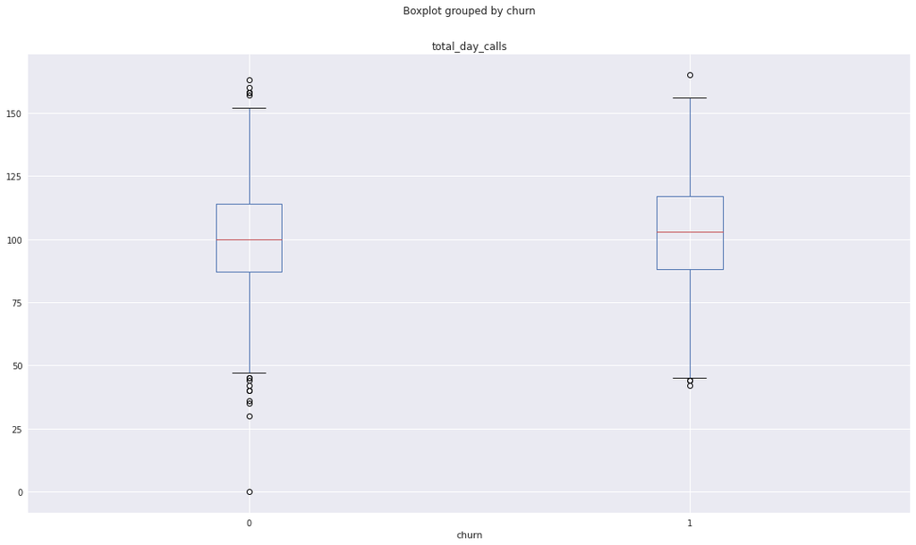

```python
# Hier zeigt sich die Auffälligkeit, dass abgewanderte Kunden zwar im Mittel etwa gleich viele Tagesanrufe getätigt haben,
# jedoch mindestens 42 Anrufe zwischen 8 und 16h, während Bestandskunden auch weniger bis hin zu gar keinen Anrufen
# unternommen haben.
#Zur weiteren Verdeutlichung kann ein Boxplot hilfreich sein:

import matplotlib.pyplot as plt
%matplotlib inline

fig, ax = plt.subplots(figsize=(18,10))

df.boxplot(column='total_day_calls', by='churn', ax=ax)
```

```python
# In den Boxplots werden die Unterschiede deutlicher: bei den Bestandkunden gibt es mehr "Ausreißer" unter- und oberhalb der
# whiskers (1,5-facher Interquartilsabstand (IQR = Q3 - Q1)). Jedoch hängt dies mit der höheren Anzahl an Bestandskunden
# gegenüber Abgewanderten zusammen. Wie das linke Boxplot zeigt gibt es nur einen Bestandskunden, der gar keine Tagesanrufe
# getätigt hat - daher gibt es bei dieser Variable insgesamt keine offensichtlichen Hinweise auf einen Zusammenhang
# mit churn
```

```python
#total_eve_calls

df.loc[:,'total_eve_calls'].describe()
df.groupby('churn')['total_eve_calls'].agg(['mean',
    'median','std', 'min', 'max'])

# Auch hier gibt es wieder mindestens einen Bestandskunden, der gar keine Anrufe getätigt hat.
# Sonst gibt es keine Auffälligkeiten.
```

| churn | mean | median | std | min | max |
| --- | --- | --- | --- | --- | --- |
| 0 | 100.038503 | 100 | 20.009725 | 0 | 170 |
| 1 | 100.859873 | 101 | 19.569774 | 48 | 168 |

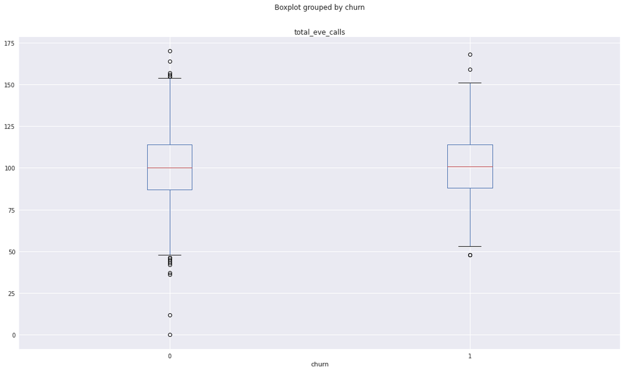

```python
fig, ax = plt.subplots(figsize=(18,10))
df.boxplot(column='total_eve_calls', by='churn', ax=ax)
```

```python
# Ähnliches Muster wie bei den Tagesanrufen, daher auch hier kein Zusammenhang vermutet
```

```python
#total_night_calls
df.loc[:,'total_night_calls'].describe()
df.groupby('churn')['total_eve_calls'].agg(['mean',
    'median','std', 'min', 'max'])
```

| churn | mean | median | std | min | max |
| --- | --- | --- | --- | --- | --- |
| 0 | 100.038503 | 100 | 20.009725 | 0 | 170 |
| 1 | 100.859873 | 101 | 19.569774 | 48 | 168 |

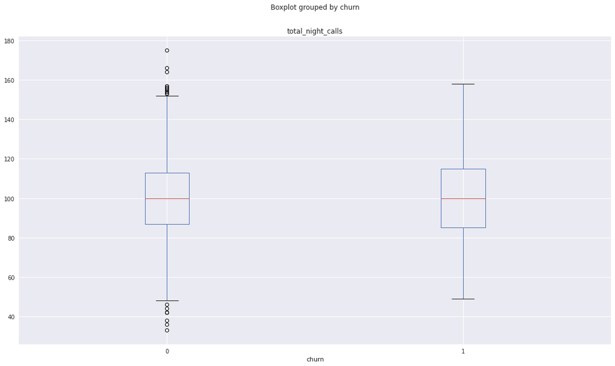

```python
fig, ax = plt.subplots(figsize=(18,10))
df.boxplot(column='total_night_calls', by='churn', ax=ax)
```

```python
# Auch bei den Nachtanrufen lässt sich nichts auffälliges oder gar ein Zusammenhang mit Kundenabwanderung erkennen.
```

```python
#customer_service_calls

print(df.loc[:,'customer_service_calls'].describe())
df.groupby('churn')['customer_service_calls'].agg(['mean',
    'median','std', 'min', 'max'])
```

```
count    3250.000000
mean        1.566462
std         1.322689
min         0.000000
25%         1.000000
50%         1.000000
75%         2.000000
max         9.000000
Name: customer_service_calls, dtype: float64
```

| churn | mean | median | std | min | max |
| --- | --- | --- | --- | --- | --- |
| 0 | 1.453041 | 1 | 1.170895 | 0 | 8 |
| 1 | 2.235669 | 2 | 1.861617 | 0 | 9 |

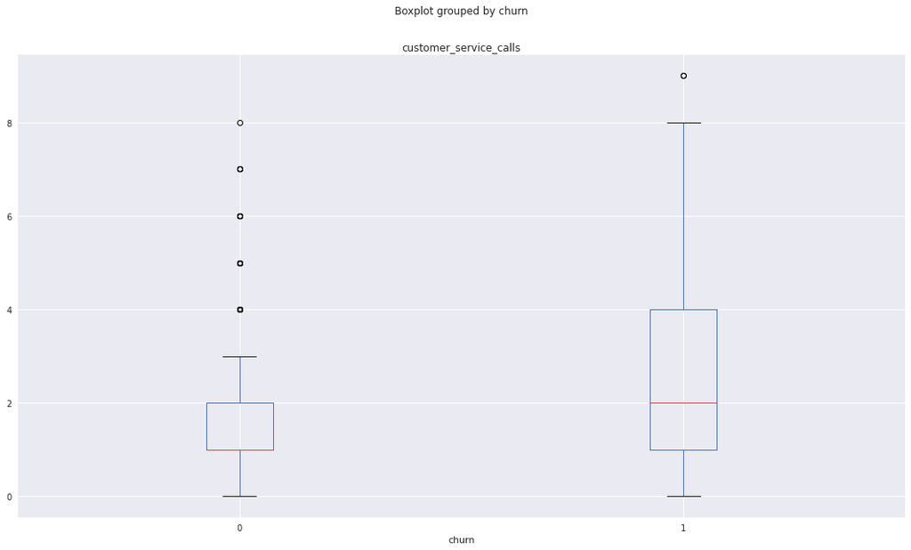

```python
# Hier könnte ein Grund für Kundenabwanderung liegen. Die Anzahl der Anrufe beim Kundenservice ist bei Abgewanderten erhöht:
# Schauen wir das mal als Boxplots an:

fig, ax = plt.subplots(figsize=(18,10))
df.boxplot(column='customer_service_calls', by='churn', ax=ax)
```

```
churn                          0         1
customer_service_calls
0                       0.866764  0.133236
1                       0.898261  0.101739
2                       0.884615  0.115385
3                       0.896471  0.103529
4                       0.548780  0.451220
5                       0.400000  0.600000
6                       0.363636  0.636364
7                       0.444444  0.555556
8                       0.500000  0.500000
9                       0.000000  1.000000
```

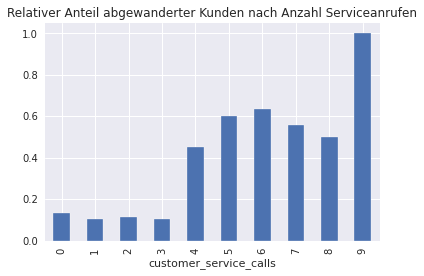

```python
# Hier ist klar zu erkennen, dass 75% der abgewanderten Kunden (3.Quartil, obere Boxbegrenzung) bis zu 4 Servicegespräche
# geführt haben, 75% der Bestandskunden nur maximal 2 Servicegespräche in Anspruch genommen haben.
# Es kann davon ausgegangen werden, dass vor der Abwanderung Probleme bestanden, welche die Kunden in Servicegesprächen
# lösen wollten. Vermutlich waren die Gespräche nicht besonders hilfreich

# Als Grenzwert, ab dem die noch vorhandenen Kunden schnellstmöglich kontaktiert werden sollten, würde ich zunächst
# zwei Serviceanrufe ansetzen (customer_service_calls >= 2):
# sowohl der Gesamtmedian als auch der für Bestandskunden liegt bei 1, während er bei
# Abgewanderten bei 2 liegt. Wenn nach dem 2. Servicegespräch das Problem nicht gelöst wurde, steigt die Chance auf eine
# Abwanderung also erheblich an.

# Dies ließe sich präziser mit einer logistischer Regression bestimmen, aber das ist erst Gegenstand von 4c),
# deswegen hier noch ein anderes Weg: Vergleich der relativen Anteile der Abgewanderten pro Serviceanruf:

df_cross = pd.crosstab(index=df.loc[:,'customer_service_calls'], columns=df.loc[:,'churn'], normalize='index')
print(df_cross)
df_cross[1].plot(kind='bar', title='Relativer Anteil abgewanderter Kunden nach Anzahl Serviceanrufen');
```

```python
# Diese Analyse zeigt, dass die Annahme eines Grenzwertes von 2 revidiert werden muss: Auch unter denjenigen, die drei
# Serviceanrufe getätigt haben, ist die Abwanderungsrate mit 10 Prozent noch gering, erst beim 4. Serviceanruf steigt
# sie dramatisch an auf 45 Prozent.

###
# Fazit: Teleconfia sollte Kunden, die viermal und mehr den Kundenservice angerufen haben, dringend kontaktieren, um das
# Risiko einer Kündigung zu verringern.
```

```python
#Extraktion der Kunden, die 4+ Serviceanrufe getätigt und  noch nicht gekündigt haben.

mask_serv = (df['customer_service_calls'] >= 4) & (df['churn'] == 0)
df_serv = df[mask_serv]
print(df_serv.head(), len(df_serv))

# Hier müssten 129 Kunden:innen angerufen werden.
```

```
         city  area_code  account_length international_plan voice_mail_plan  \
3    Orlando1        321              21                 no             yes
55   Orlando1        321              65                 no             yes
76   Orlando1        321              74                 no             yes
80   Orlando1        321              75                 no             yes
150  Orlando1        321             101                 no              no

     number_vmail_messages  total_day_minutes  total_day_calls  \
3                       31              135.9               90
55                      34              208.8              119
76                      27              154.1              122
80                      21              175.8               97
150                      0              232.7              114

     total_day_charge  total_eve_minutes  total_eve_calls  total_eve_charge  \
```

[output cut: 19 more lines]

## **4c)** Fließkomma-Variable als Indikator für Kundenabwanderung eignen - Bestimmung der **Grenzwerte** mit **logistischer Regression**

```python
# Was waren nochmal Fließkomma-Variablen im Datensatz?
df.dtypes
```

```
city                      category
area_code                    int64
account_length               int64
international_plan          object
voice_mail_plan             object
number_vmail_messages        int64
total_day_minutes          float64
total_day_calls              int64
total_day_charge           float64
total_eve_minutes          float64
total_eve_calls              int64
total_eve_charge           float64
total_night_minutes        float64
total_night_calls            int64
total_night_charge         float64
customer_service_calls       int64
churn                        int64
phone_num                    int64
dtype: object
```

```python
# Zu untersuchen sind also:
# 1. total_day_minutes
# 2. total_day_charge
# 3. total_eve_minutes
# 4. total_eve_charge
# 5. total_night_minutes
# 6. total_night_charge
```

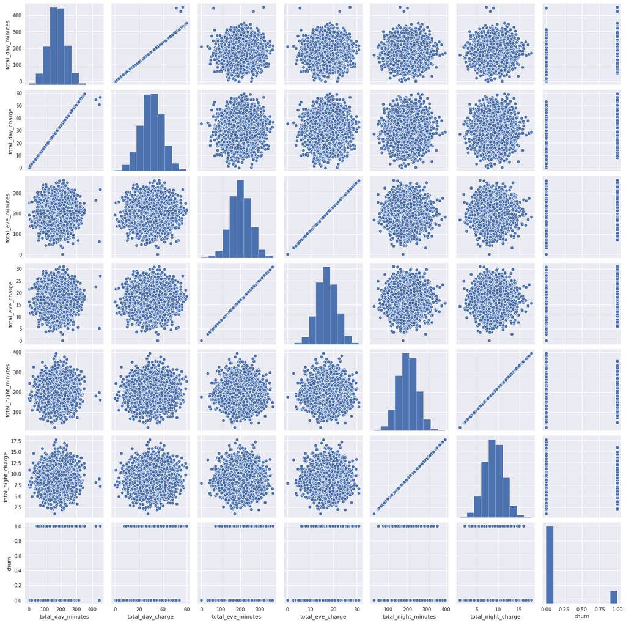

```python
#Kopieren nur der float Variablen und churn in extra dataframe, um sparsamer das Übersichts-Scatterplot zu generieren:
df_scatter = df[['total_day_minutes', 'total_day_charge', 'total_eve_minutes',
                          'total_eve_charge', 'total_night_minutes', 'total_night_charge', 'churn']].copy()
df_scatter.head()
#print(pd.plotting.scatter_matrix(df_scatter));

# Das ist noch nicht übersichtlich genug. Vielleicht besser mit seaborn:

import seaborn as sns
sns.pairplot(df_scatter)
```

```python
# Die seaborn Übersicht zeigt sehr perfekte (Nicht-)Zusammenhänge sowohl zwischen den Gebühren und den entsprechenden Anruf-
# minuten zu den verschiedenen Tageszeiten (perfekter Zusammenhang: Punkte auf einer Linie) als auch die Unabhängigkeit
# der drei Tagesabschnitte von einander in Form der Punktewolken.

# Erstens zeigt die Übersicht, dass für die logistische Regression nur drei Variablen getestet werden müssen und sollten
# (sonst Problem der Multikollinearität): es reichen entweden die Gebühren oder die Anrufdauer, da beides fast perfekt
# korreliert.

# Zweitens zeigt die Übersicht, dass der Zusammenhang für den Tag (8-16 Uhr) etwas anders ist: der Anstieg ist steiler,
# d.h. die Gebühren nehmen mit zunehmender Anrufdauer schneller zu als abends oder nachts. Desweiteren gibt es drei Outlier
# mit sehr hoher Anrufdauer, die etwas weniger gebühren zahlen und damit nicht auf der Punktelinie liegen.

# Vergleichen wir als nächstes die Gebühren zu den drei Tageszeiten zwischen Abgewanderten und Bestandskunden:
```

```python
print(df_scatter.groupby('churn')['total_day_charge'].mean())
print(df_scatter.groupby('churn')['total_eve_charge'].mean())
print(df_scatter.groupby('churn')['total_night_charge'].mean())
```

```
churn
0    29.812141
1    35.280510
Name: total_day_charge, dtype: float64
churn
0    16.907557
1    18.063312
Name: total_eve_charge, dtype: float64
churn
0    9.009996
1    9.239830
Name: total_night_charge, dtype: float64
```

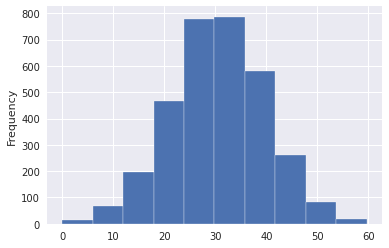

```python
# Histogramm 'total_day_charge' um Outlier noch genauer aufzuspüren

df.loc[:,'total_day_charge'].plot(kind='hist')

#Keine Outlier zu sehen, Verteilung sieht gut aus für Regression
```

```python
# Die Gebühren für Tagesanrufe sind bei den Abgewanderten deutlich erhöht gegenüber den Gebühren, die Bestandkunden zahlen.
# 35 statt 30 Dollar. Diese Variable sollte also für eine logistische Regression genutzt werden.

# Zuvor, optional ein Welch-Test, um zu prüfen, ob die Mittelwertunterschiede signifikant sind (ähnlich wie bei Chi Quadrat
# oben): Verfahren zum Vergleich der Mittelwerte zweier unabhängiger Gruppen (hier: churn 0/1).
# Im Gegensatz zum klassischen Student-t-Test setzt er keine gleichen Varianzen und ist daher robuster
# bei unterschiedlichen Gruppengrößen

from scipy.stats import ttest_ind

x = df_scatter.loc[df['churn'] == 0, 'total_day_charge']
y = df_scatter.loc[df['churn'] == 1, 'total_day_charge']

t, p = ttest_ind(x, y, equal_var=False)

print("t-Wert:", t)
print("p-Wert:", p)
```

```
t-Wert: -9.707587443464327
p-Wert: 1.0853916408786588e-20
```

```python
# Der t Wert von -9.7 ist höchst signifikant (p<0.001), damit ist der Mittelwertunterschied überzufällig groß und es handelt
# sich aller Wahrscheinlichkeit nach, um einen systematischen Zusammenhang zwischen Tagesgebühren und churn.

# Zur Sicherheit prüfen wir auch mal eve, da gibt es ja auch einen kleinen Unterschied:
from scipy.stats import ttest_ind

x = df_scatter.loc[df['churn'] == 0, 'total_eve_charge']
y = df_scatter.loc[df['churn'] == 1, 'total_eve_charge']

t, p = ttest_ind(x, y, equal_var=False)

print("t-Wert:", t)
print("p-Wert:", p)
```

```
t-Wert: -5.3210158429388414
p-Wert: 1.4356974302105806e-07
```

```python
# Der p-Wert ist zwar größer, aber immer noch höchst signifikant (p<0.001). Wir sollten also eine zweite log. Regr. auch
# damit durchführen.

from scipy.stats import ttest_ind

x = df_scatter.loc[df['churn'] == 0, 'total_night_charge']
y = df_scatter.loc[df['churn'] == 1, 'total_night_charge']

t, p = ttest_ind(x, y, equal_var=False)

print("t-Wert:", t)
print("p-Wert:", p)
```

```
t-Wert: -2.130383752292935
p-Wert: 0.033504473095579024
```

```python
# Bei Nachtgebühren ist der Unterschied nur noch signifikant (p<0.05). Das genügt bei einer so hohen Fallzahl (n>3000)
# nicht, um mit ausreichend hoher Sicherheit von einem systematischen Zusammenhang auszugehen (wenn vorhanden, dann auch nur
# klein mit 23 Cent höheren Gebühren im Schnitt)
```

```python
#Logistische Regression mit Tagesgebühren als unabhängiger Variable und churn als abhängiger (vorherzusagender):
import statsmodels.formula.api as smf
model = smf.logit(formula='churn ~ total_day_charge',
                  data=df_scatter)
results = model.fit()
results.summary()
```

```
Optimization terminated successfully.
         Current function value: 0.391682
         Iterations 6
```

Logit Regression Results

| Dep. Variable: | churn | No. Observations: | 3250 |
| --- | --- | --- | --- |
| Model: | Logit | Df Residuals: | 3248 |
| Method: | MLE | Df Model: | 1 |
| Date: | Thu, 29 Jan 2026 | Pseudo R-squ.: | 0.05345 |
| Time: | 13:48:39 | Log-Likelihood: | -1273.0 |
| converged: | True | LL-Null: | -1344.9 |
| Covariance Type: | nonrobust | LLR p-value: | 3.992e-33 |

|  | coef | std err | z | P>\|z\| | [0.025 | 0.975] |
| --- | --- | --- | --- | --- | --- | --- |
| Intercept | -3.9566 | 0.206 | -19.219 | 0.000 | -4.360 | -3.553 |
| total_day_charge | 0.0670 | 0.006 | 11.539 | 0.000 | 0.056 | 0.078 |

```python
#Interpretation:
# Pseudo-R-squared als Maß für die Modellgüte ist mit 0.05 = 5% erklärter Varianz eher gering (zwischen 20-40% wäre eine
# sehr gute Modellanpassung)

# Interessant sind noch die Koeffizienten, die allerdings nicht so direkt wie bei einer linearen Regr. zu interpretieren sind:
# das positive beta (coeff von total_day_charge) deutet darauf hin, dass mit steigenden Tagesgebühren die Abwanderungs-
# wahrscheinlichkeit zunimmt.
```

```python
# Erwartete Werte für churn aufgrund der Höhe der Tagesgebühren mit dem Modell vorhersagen
print(df_scatter.describe())
# Das Maximum für total_day_charge ist 59
import math
X = pd.Series(range(101)) # Werte von 0 bis 100 erzeugen (Spannweite der theoretischen Gebühren)

# Parameterwerte in Varibalen speichern
intercept = results.params['Intercept']
slope = results.params['total_day_charge']

#Formel der logitischen regression, die Eulersche Zahl (e) enthält (dafür oben math importiert):
p_y = 1 / (1 + math.e**-(intercept + (slope * X)))
p_y
```

```
       total_day_minutes  total_day_charge  total_eve_minutes  \
count        3250.000000       3250.000000        3250.000000
mean          180.134892         30.604634         200.880462
std            54.973530          9.277527          50.558316
min             0.000000          0.000000           0.000000
25%           143.725000         24.435000         166.600000
50%           179.750000         30.560000         201.400000
75%           216.800000         36.860000         235.300000
max           448.600000         59.640000         363.700000

       total_eve_charge  total_night_minutes  total_night_charge        churn
count       3250.000000          3250.000000         3250.000000  3250.000000
mean          17.075052           200.960677            9.043305     0.144923
std            4.297444            50.716411            2.282286     0.352077
min            0.000000            23.200000            1.040000     0.000000
25%           14.160000           167.100000            7.520000     0.000000
50%           17.120000           201.400000            9.060000     0.000000
75%           20.000000           235.675000           10.607500     0.000000
max           30.910000           395.000000           17.770000     1.000000
```

```
0      0.018769
1      0.020043
2      0.021403
3      0.022852
4      0.024397
         ...
96     0.922423
97     0.927084
98     0.931486
99     0.935641
100    0.939559
Length: 101, dtype: float64
```

```
Grenzwert:  60
```

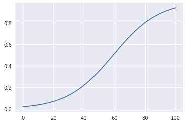

```python
# Die vorhergesagten Abwanderungswahrscheinlichkeiten zeigen, dass erst ab einer Tagesgebührenhöhe von 60 Dollar, die Wahr-
# scheinlichkeit über 50% steigt, d.h. erst ab dann ist die Wahrsch. einer Abwanderung höher als die eines Verbleibens.
# Der genaue Grenzwert, wo die Wahrscheinlichkeit 50 Prozent und höher ist, berechnet sich so:

print('Grenzwert: ', p_y[p_y >= 0.5].index[0])

# Noch ein Blick auf die Regressionsgerade:
p_y.plot() #weiter unten in schönerer Form
```

```python
# Logit. Regression für die Abendgebühren
model_eve = smf.logit(formula='churn ~ total_eve_charge',
                  data=df_scatter)
results_eve = model_eve.fit()
results_eve.summary()
```

```
Optimization terminated successfully.
         Current function value: 0.409289
         Iterations 6
```

Logit Regression Results

| Dep. Variable: | churn | No. Observations: | 3250 |
| --- | --- | --- | --- |
| Model: | Logit | Df Residuals: | 3248 |
| Method: | MLE | Df Model: | 1 |
| Date: | Thu, 29 Jan 2026 | Pseudo R-squ.: | 0.01090 |
| Time: | 13:48:52 | Log-Likelihood: | -1330.2 |
| converged: | True | LL-Null: | -1344.9 |
| Covariance Type: | nonrobust | LLR p-value: | 6.118e-08 |

|  | coef | std err | z | P>\|z\| | [0.025 | 0.975] |
| --- | --- | --- | --- | --- | --- | --- |
| Intercept | -2.8827 | 0.217 | -13.299 | 0.000 | -3.308 | -2.458 |
| total_eve_charge | 0.0633 | 0.012 | 5.373 | 0.000 | 0.040 | 0.086 |

```
0      0.053014
1      0.056286
2      0.059747
3      0.063407
4      0.067275
         ...
96     0.960789
97     0.963107
98     0.965293
99     0.967354
100    0.969296
Length: 101, dtype: float64
Grenzwert:  46
```

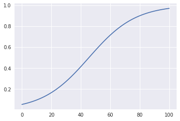

```python
# Das Pseudo-R-squared ist noch kleiner mit nur 1% erklärter Varianz. D.h. es kann kaum von einer ausreichenden Modell-
# anpassung gesprochen werden.
# Trotzdem zur Veranschaulichung mal y Werte vorhersagen:

X2 = pd.Series(range(101)) # Werte von 0 bis 100 erzeugen (Spannweite der theoretischer Gebühren)

# Parameterwerte für eve in Varibalen speichern
intercept2 = results_eve.params['Intercept']
slope2 = results_eve.params['total_eve_charge']

#Formel der logitischen Regression für eve:
p_y2 = 1 / (1 + math.e**-(intercept2 + (slope2 * X2)))
print(p_y2)

print('Grenzwert: ', p_y2[p_y2 >= 0.5].index[0])
p_y2.plot()
```

```
3
```

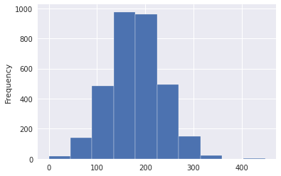

```python
# Hier liegt der Grenzwert bei 46 Dollar (auch oberhalb des Maximums) - aber das nur der Vollständigkeit halber. Interessant
# sind im folgenden nur die Tagesbühren bzw. -minuten:

# Da es für eine Kommunikation an teleconfia schwierig ist zusagen, der Grenzwert für eine wahrsch. Abwanderung läge bei
# 60 Dollar, wenn kein einziger Kunde so hohe Tagesgebühren hatte (trotzdem möglicher Grenzwert, weil ja auch Leute mit
# z.B. 40% Wahrscheinlichkeit abwandern). Deshalb besser die Anrufdauer in Minuten, die ja hoch korreliert mit den Ge-
# bühren ist und daher zu einem vergleichbaren Modell führen wird. Zuvor jedoch wieder ein Histogramm, um die Verteilung
# zu prüfen

# Histogramm 'total_day_minutes'

df.loc[:,'total_day_minutes'].plot(kind='hist')
# Hier gibt es drei Outlier, die auch oben schon in der Scattermatrix zu sehen waren,. Wir setzen sie auf nan, um die
# Analysen zu unserem Grenzwert nicht zu verzerren.
outlier = (df['total_day_minutes'] > 400).sum()
print(outlier)
```

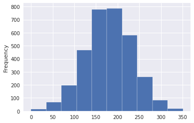

```python
mask_out = df_scatter.loc[:,'total_day_minutes'] > 400
df_scatter.loc[mask_out, 'total_day_minutes'] = np.nan
df_scatter.loc[:,'total_day_minutes'].plot(kind='hist')
```

```python
# Die Outlier sind "deaktiviert"
```

```python
#Logistsche Regression für Anrufdauer tagsüber

model_daymin = smf.logit(formula='churn ~ total_day_minutes',
                  data=df_scatter)
results_daymin = model_daymin.fit()
print(results_daymin.summary())

intercept3 = results_daymin.params['Intercept']
slope3 = results_daymin.params['total_day_minutes']

X3 = pd.Series(range(1001))

#Formel der logitischen Regression für daymin:
p_y3 = 1 / (1 + math.e**-(intercept3 + (slope3 * X3)))
print(p_y3)

print('Grenzwert: ', p_y3[p_y3 >= 0.5].index[0])
```

```
Optimization terminated successfully.
         Current function value: 0.391399
         Iterations 6
                           Logit Regression Results
==============================================================================
Dep. Variable:                  churn   No. Observations:                 3247
Model:                          Logit   Df Residuals:                     3245
Method:                           MLE   Df Model:                            1
Date:                Thu, 29 Jan 2026   Pseudo R-squ.:                 0.05217
Time:                        13:49:08   Log-Likelihood:                -1270.9
converged:                       True   LL-Null:                       -1340.8
Covariance Type:            nonrobust   LLR p-value:                 2.782e-32
=====================================================================================
                        coef    std err          z      P>|z|      [0.025      0.975]
-------------------------------------------------------------------------------------
Intercept            -3.9379      0.206    -19.085      0.000      -4.342      -3.534
total_day_minutes     0.0113      0.001     11.389      0.000       0.009       0.013
=====================================================================================
0       0.019116
1       0.019329
2       0.019544
3       0.019761
4       0.019981
          ...
996     0.999329
997     0.999336
998     0.999344
999     0.999351
1000    0.999358
Length: 1001, dtype: float64
Grenzwert:  349
```

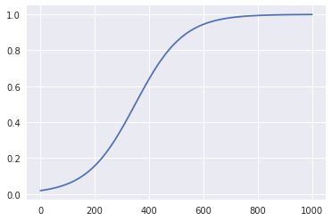

```python
# Der Grenzwert ist 349, während das Maximum (mit Outliers, siehe oben) bei 448 Minuten liegt. Das läßt sich besser an teleconfia
# kommunizieren. Zum Abschluss noch der Plot:

p_y3.plot()
```

```python
# Fazit: Kunden, die zwischen 8 und 16 Uhr mehr als 349 Minuten telefonieren, werden wahrscheinlich abwandern und
# sollten/könnten daher mit besonderen Vieltelefonierer-Tarifen zum Verbleibt motiviert werden.
```

```python
#Extraktion der Kunden mit so hoher Anrufdauer tagsüber, dass die Gefahr einer Abwanderung droht.

mask_dauer = (df['total_day_minutes'] >= p_y3[p_y3 >= 0.5].index[0]) & (df['churn'] == 0)
df_dauer = df[mask_dauer]
print(df_dauer.head())

#Das trifft nur auf einen Kunden in Tallahassee zu. Wahrscheinlich ist es besser, schon etwas vorher anzusetzen und nicht
# zu warten bis die Wahrscheinlichkeit 50% erreicht hat. Schauen wir mal auf eine 33%ige Wahrscheinlichkeit:

print('Grenzwert 33%: ', p_y3[p_y3 >= 0.33].index[0])
mask_dauer2 = (df['total_day_minutes'] >= p_y3[p_y3 >= 0.33].index[0]) & (df['churn'] == 0)
df_dauer2 = df[mask_dauer2]
print(df_dauer2.head(), len(df_dauer2))

# Nach dieser Rechnung können 20 Kunden kontaktiert werden - die 287+ Minuten telefoniert haben -
# um bessere Konditionen auszuhandeln.
```

```
             city  area_code  account_length international_plan  \
3145  Tallahassee        850              84                yes

     voice_mail_plan  number_vmail_messages  total_day_minutes  \
3145              no                      0              443.2

      total_day_calls  total_day_charge  total_eve_minutes  total_eve_calls  \
3145               71              50.9               61.9               88

      total_eve_charge  total_night_minutes  total_night_calls  \
3145              5.26                196.9                 89

      total_night_charge  customer_service_calls  churn  phone_num
3145                8.86                       2      0       9999
Grenzwert 33%:  287
         city  area_code  account_length international_plan voice_mail_plan  \
365  Orlando2        407              67                 no              no
444  Orlando2        407              98                 no              no
627    Miami1        305              48                 no              no
632    Miami1        305              50                 no              no
634    Miami1        305              50                 no             yes

     number_vmail_messages  total_day_minutes  total_day_calls  \
365                      0              310.4               97
444                      0              288.1              101
627                      0              300.4               94
632                      0              301.7               82
634                     31              302.7               93

     total_day_charge  total_eve_minutes  total_eve_calls  total_eve_charge  \
365             52.77               66.5              123              5.65
444             48.98              137.9               93             11.72
627             51.07              133.2              103             11.32
632             51.29              167.1              118             14.20
634             51.46              240.5              119             20.44

     total_night_minutes  total_night_calls  total_night_charge  \
365                246.5                 99               11.09
444                206.5                 88                9.29
627                197.4                 94                8.88
632                 72.2                 89                3.25
634                193.9                103                8.73

     customer_service_calls  churn  phone_num
365                       4      0       6784
444                       0      0       7452
627                       2      0       6696
632                       1      0       9037
634                       3      0       6436   20
```

## **5)** **Visualisierungen** der Ergebnisse

```python
#Kundenabwanderung gesamt
pd.crosstab(index=df.loc[:,'churn'], columns='count', normalize='columns')
```

| col_0 churn | count |
| --- | --- |
| 0 | 0.855077 |
| 1 | 0.144923 |

```python
# Stadtgebiete: Balkendiagramm
city_churn_cross_rel = pd.crosstab(index=df.loc[:,'city'], columns=df.loc[:,'churn'], normalize='index')
city_churn_cross_rel=city_churn_cross_rel.sort_values(
    by=city_churn_cross_rel.columns[1], ascending=True)
print(city_churn_cross_rel)
```

```
churn                   0         1
city
Tampa            0.967742  0.032258
West Palm Beach  0.965368  0.034632
Tallahassee      0.937729  0.062271
Clearwater       0.928270  0.071730
Sarasota         0.905738  0.094262
Miami2           0.894737  0.105263
Miami1           0.862205  0.137795
Daytona Beach    0.831502  0.168498
Orlando2         0.811448  0.188552
Cape Coral       0.779310  0.220690
Orlando1         0.764310  0.235690
Jacksonville     0.697819  0.302181
```

```
churn                      0         1
international_plan
no                  0.884799  0.115201
yes                 0.579114  0.420886
```

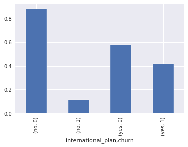

```python
# International plan: gruppiertes Säulendiagramm

cross_ausland = pd.crosstab(index=df.loc[:,'international_plan'], columns=df.loc[:,'churn'], normalize='index')
print(cross_ausland)
df.groupby('international_plan')['churn'].value_counts(normalize=True).plot(kind='bar')
```

```
churn                          0         1
customer_service_calls
0                       0.866764  0.133236
1                       0.898261  0.101739
2                       0.884615  0.115385
3                       0.896471  0.103529
4                       0.548780  0.451220
5                       0.400000  0.600000
6                       0.363636  0.636364
7                       0.444444  0.555556
8                       0.500000  0.500000
9                       0.000000  1.000000
```

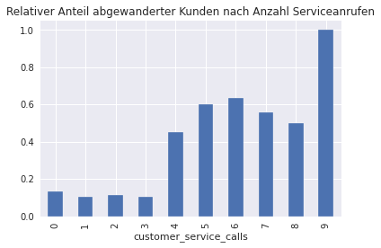

```python
#Säulendiagramm für Anzahl Anrufe beim Kundenservice
df_cross = pd.crosstab(index=df.loc[:,'customer_service_calls'], columns=df.loc[:,'churn'], normalize='index')
print(df_cross)
df_cross[1].plot(kind='bar', title='Relativer Anteil abgewanderter Kunden nach Anzahl Serviceanrufen');
```

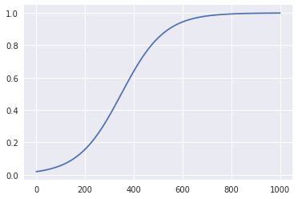

```python
p_y3.plot()
```

```python
colors
```

```
['#4C72B0', '#55A868', '#C44E52', '#8172B2', '#CCB974', '#64B5CD']
```

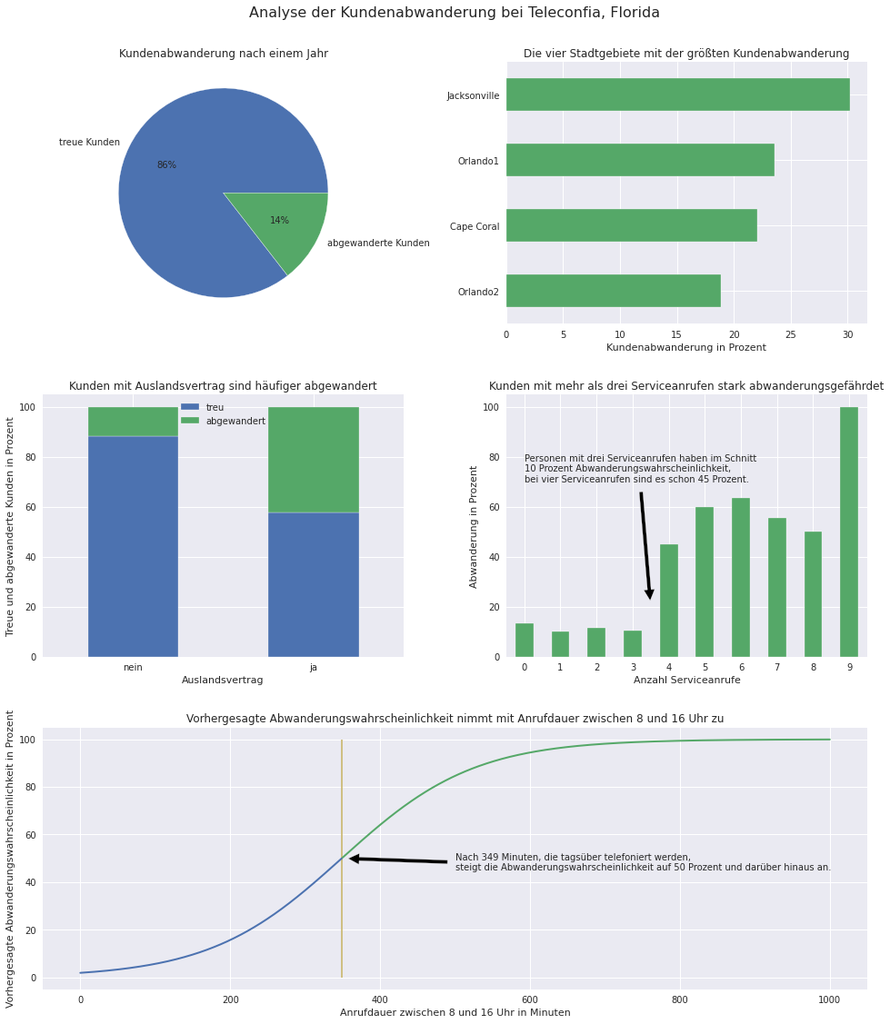

```python
import matplotlib.gridspec as gridspec #nötig, um variierende Anzahl an axes in den Zeilen zu haben

###Definition Gesamtbild
fig = plt.figure(figsize=(14, 16))
plt.style.use('seaborn')
colors = plt.rcParams['axes.prop_cycle'].by_key()['color'] #Speichern der seaborn Farbpalette, um Farben zu callen

gs = gridspec.GridSpec(3, 2)  # 3 Zeilen, 2 Spalten

ax1 = fig.add_subplot(gs[0, 0])   # Zeile 0, Spalte 0
ax2 = fig.add_subplot(gs[0, 1])   # Zeile 1, Spalte 1
ax3 = fig.add_subplot(gs[1, 0])   # Zeile 1, Spalte 0
ax4 = fig.add_subplot(gs[1, 1])   # Zeile 1, Spalte 1
ax5 = fig.add_subplot(gs[2, :])   # Zeile 2, über beide Spalten


#################
#Gesamtübersicht: Tortendiagramm Kundenabwanderung
cross_tab_churns = pd.crosstab(index=df.loc[:,'churn'], columns='count', normalize='columns')

labels = ['treue Kunden', 'abgewanderte Kunden']
cross_tab_churns.plot(kind='pie', y='count', ax=ax1, legend=False, labels=labels, autopct='%1.0f%%')

ax1.axis('off')  # Keine Achsen und Linien anzeigen
ax1.set(title='Kundenabwanderung nach einem Jahr')

##########################
#Balkendiagramm der Städte
city_churn_cross_rel2 = city_churn_cross_rel *100
city_churn_cross_rel2.iloc[-4:,1].plot(kind='barh', ax=ax2, color='#55A868')
ax2.set(title='Die vier Stadtgebiete mit der größten Kundenabwanderung',
        ylabel='', xlabel='Kundenabwanderung in Prozent')

###########################
#Gestapeltes Säulendiagramm der Abwanderung nach Auslandsverträgen
cross_ausland2 = cross_ausland * 100
cross_ausland2.plot(kind='bar',stacked=True, ax=ax3)
labels2 = ['nein', 'ja']
ax3.set(title='Kunden mit Auslandsvertrag sind häufiger abgewandert', xlabel='Auslandsvertrag', xticklabels=labels2,
       ylabel='Treue und abgewanderte Kunden in Prozent')
ax3.xaxis.set_tick_params(labelrotation=0)
ax3.legend(['treu', 'abgewandert'], loc='upper center')

###############
#Säulendiagramm für Anzahl Anrufe beim Kundenservice
df_cross2 = df_cross *100
df_cross2[1].plot(kind='bar', ax=ax4, color='#55A868')
ax4.set(title='Kunden mit mehr als drei Serviceanrufen stark abwanderungsgefährdet', xlabel='Anzahl Serviceanrufe',
        ylabel='Abwanderung in Prozent')
ax4.xaxis.set_tick_params(labelrotation=0)

    #Annotation für das Säulendiagramm
ann_ax4 = ax4.annotate(s='Personen mit drei Serviceanrufen haben im Schnitt\n'
'{} Prozent Abwanderungswahrscheinlichkeit, \n'
'bei vier Serviceanrufen sind es schon {} Prozent.'.format(int(df_cross2.iloc[3,1].round()),
                                                           int(df_cross2.iloc[4,1].round())),
                         xy=[3.5, 20],
                         xytext=[0, 70],
                         arrowprops=dict(facecolor='black', shrink=0.05))

###############
#Liniendiagramm aus der logistischen Regression zur Anrufdauer tagsüber
p_y3_2 = p_y3 *100
#p_y3_2.plot(ax=ax5, color='#55A868') # einfarbige Linie

x_split = p_y3_2[p_y3_2>=50].index[0] # Datenreihe an Grenzwert splitten, um zweifarbige Linie zu zeichnen
mask = p_y3_2.index <= x_split

p_y3_2[mask].plot(ax=ax5, color='#4C72B0', linewidth=2) # Zweifarbige Linie, für kohärentes Farbschema
p_y3_2[~mask].plot(ax=ax5, color='#55A868', linewidth=2)

ax5.vlines(x=p_y3_2[p_y3_2>=50].index[0], ymin=0, ymax=100, colors='#CCB974')
ax5.set(title='Vorhergesagte Abwanderungswahrscheinlichkeit nimmt mit Anrufdauer zwischen 8 und 16 Uhr zu',
        xlabel='Anrufdauer zwischen 8 und 16 Uhr in Minuten',
        ylabel='Vorhergesagte Abwanderungswahrscheinlichkeit in Prozent')

    #Annotation für die Regressionskurve
ann_ax5 = ax5.annotate(s='Nach {} Minuten, die tagsüber telefoniert werden, \n'
'steigt die Abwanderungswahrscheinlichkeit auf 50 Prozent und darüber hinaus an.'.format(p_y3_2[p_y3_2 >= 50].index[0]),
                         xy=[350, 50],
                         xytext=[500, 45],
                         arrowprops=dict(facecolor='black', shrink=0.05))

################
#Abschlusslayout
fig.suptitle('Analyse der Kundenabwanderung bei Teleconfia, Florida', fontsize=16)
fig.tight_layout(rect=[0, 0, 1, 0.95]);
```

```python
fig.savefig('results_teleconfia')
```

## **6)** **Formulierung** der Empfehlungen

In Jacksonville, Orlando 1 und 2 sowie Cape Coral ist die Kunderabwanderung am größten. Die Plakatkampgne sollte sich auf diese Stadtgebiete konzentrieren.

Abwanderungsbereite Kunden sind erstens besonders solche, die einen Vertrag mit Sonderkonditionen für Anrufe ins Ausland abge schlossen haben. Offenbar sind die Konditionen nicht so attraktiv wie beabsichtigt. Telefoncia sollte diese Kunden fragen, welche konkreten attraktiven Konditionen für Auslandsanrufe gewünscht sind. Es gibt 183 Kund:innen mit solchen Sonderkonditionen, die noch abgewandert sind.

Zweitens sind Kunden mit mehr als drei Serviceanrufen stark abwanderungsbereit. Anhaltende technische Störungen, die der Support nicht klären konnte, scheinen hier ein Problem zu sein. In der individuellen Kundenansprache sollten die verbliebenen Kunden:innen mit vier und mehr Serviceanrufen kontaktiert werden (n=129), um in Erfahrung zu bringen, was genau die Probleme sind.

Drittens sind Kunden, die tagsüber viel telefonieren (hohe Anrufdauer) abwanderungsbereiter. Ab einer (monatlichen?) Anrufdauer von 349 Minuten steigt die Abwanderungswahrscheinlichkeit schon auf 50 Prozent (So hoch ist sie ebenfalls bei einer Gebührenhöhe von 60 Dollar). Es gibt jedoch nur noch einen einzigen Bestandskunden, auf den oder die das zutrifft. Deshalb sollten schon Kunden ansprochen werden, deren Abwanderungswahrscheinlichkeit geringer, aber immer noch “ausreichend” hoch ist, dass sich eine gezielte Ansprache lohnt. Beispielhaft wurde hier eine 33%ige Wahrscheinlichkeit gewählt, die mit einem Grenzwert von 287 Anrufminuten tagsüber einhergeht. Die 20 Kund:innen, auf dies zutrifft, sollten kontaktiert werden, um in Erfahrung zu bringen, ob sie z.B. spezielle Vieltelefonierertarife zum Verbleib bei Teleconfia motivieren könnten.